# Cluster Analysis

WDI Indicators

Ali Gorji

2018-07-14 21:52:31

> با توجه به داده بانک جهانی به سوالات زیر پاسخ دهید. برای استفاده از داده از سه فایل زیر استفاده نمایید. داده نام کشورها: WDICountry داده نام سری های زمانی: WDISeries داده کل: WDIData در صورتی که داده را در اختیار ندارید می توانید از بسته WDI استفاده نموده و داده های مورد نظر را استخراج نمایید.

```r
library(readr)
library(dplyr)
library(highcharter)
library(ggplot2)
library(tidyr)
library(stringr)
WDICountry = read_csv("WDI_csv/WDICountry.csv")
WDISeries = read_csv("WDI_csv/WDISeries.csv")
WDIData = read_csv("WDI_csv/WDIData.csv")
```

۱. ده کشور فقیر دنیا را بیابید. نمودار درآمد روزانه آنها را رسم کنید. چند درصد از اعضای این کشورها زیر خط فقر هستند؟ متوسط عمر در این کشورها چقدر است؟

```r
WDISeries %>% filter(Topic == "Poverty: Poverty rates")
```

```
## # A tibble: 12 x 21
##    `Series Code`  Topic `Indicator Name` `Short definiti… `Long definitio…
##    <chr>          <chr> <chr>            <chr>            <chr>
##  1 SI.POV.DDAY    Pove… Poverty headcou… Poverty headcou… Poverty headcou…
##  2 SI.POV.GAPS    Pove… Poverty gap at … Poverty gap at … Poverty gap at …
##  3 SI.POV.LMIC    Pove… Poverty headcou… Poverty headcou… Poverty headcou…
##  4 SI.POV.LMIC.GP Pove… Poverty gap at … Poverty gap at … Poverty gap at …
##  5 SI.POV.NAGP    Pove… Poverty gap at … <NA>             Poverty gap at …
##  6 SI.POV.NAHC    Pove… Poverty headcou… <NA>             National povert…
##  7 SI.POV.RUGP    Pove… Rural poverty g… <NA>             Rural poverty g…
##  8 SI.POV.RUHC    Pove… Rural poverty h… <NA>             Rural poverty h…
##  9 SI.POV.UMIC    Pove… Poverty headcou… Poverty headcou… Poverty headcou…
## 10 SI.POV.UMIC.GP Pove… Poverty gap at … Poverty gap at … Poverty gap at …
## 11 SI.POV.URGP    Pove… Urban poverty g… <NA>             Urban poverty g…
## 12 SI.POV.URHC    Pove… Urban poverty h… <NA>             Urban poverty h…
## # ... with 16 more variables: `Unit of measure` <chr>, Periodicity <chr>,
## #   `Base Period` <chr>, `Other notes` <chr>, `Aggregation method` <chr>,
## #   `Limitations and exceptions` <chr>, `Notes from original
## #   source` <chr>, `General comments` <chr>, Source <chr>, `Statistical
## #   concept and methodology` <chr>, `Development relevance` <chr>,
## #   `Related source links` <chr>, `Other web links` <chr>, `Related
## #   indicators` <chr>, `License Type` <chr>, X21 <chr>
```

```r
Data = WDIData %>% rowwise()
WDIData %>% filter(`Indicator Code` == "SI.POV.NAHC") %>% rowwise() %>%  mutate(Average = mean(c(`2000`,`2001`,`2002`,`2003`,`2004`,`2005`,`2006`,`2007`,`2008`,`2009`,`2010`,`2011`,`2012`,`2013`,`2014`,`2015`,`2016`,`2017`), na.rm = T)) %>% arrange(desc(Average)) %>% head(10) %>% .$`Country Name` -> pour_countries

#Income
WDIData %>% filter(`Indicator Code` == "BM.GSR.FCTY.CD" & `Country Name` %in% pour_countries) %>% rowwise() %>% mutate(Average = mean(c(`2000`,`2001`,`2002`,`2003`,`2004`,`2005`,`2006`,`2007`,`2008`,`2009`,`2010`,`2011`,`2012`,`2013`,`2014`,`2015`,`2016`,`2017`), na.rm = T)) %>% filter(!is.na(Average)) -> poorIncome

hchart(poorIncome %>% select(Country = `Country Name`, AverageIncome = Average), type = "column", hcaes(x = Country, y = AverageIncome)) %>% hc_add_theme(hc_theme_flat())
```

[interactive chart not shown]

```r
#Poverty line
WDIData %>% filter(`Indicator Code` == "SI.POV.RUHC" & `Country Name` %in% pour_countries) %>% rowwise() %>% mutate(Average = mean(c(`2000`,`2001`,`2002`,`2003`,`2004`,`2005`,`2006`,`2007`,`2008`,`2009`,`2010`,`2011`,`2012`,`2013`,`2014`,`2015`,`2016`,`2017`), na.rm = T)) %>% filter(!is.na(Average)) -> poorPovertyline
hchart(poorIncome %>% select(Country = `Country Name`, AverageUnderPovertyLinePercent = Average), type = "column", hcaes(x = Country, y = AverageUnderPovertyLinePercent)) %>% hc_add_theme(hc_theme_flat())
```

[interactive chart not shown]

```r
#Average Life Expectance
WDIData %>% filter(`Indicator Code` == "SP.DYN.LE00.IN" & `Country Name` %in% pour_countries) %>% rowwise() %>% mutate(Average = mean(c(`2000`,`2001`,`2002`,`2003`,`2004`,`2005`,`2006`,`2007`,`2008`,`2009`,`2010`,`2011`,`2012`,`2013`,`2014`,`2015`,`2016`,`2017`), na.rm = T)) %>% filter(!is.na(Average)) -> poorPovertyline
hchart(poorIncome %>% select(Country = `Country Name`, AverageLifeExpectance = Average), type = "column", hcaes(x = Country, y = AverageLifeExpectance)) %>% hc_add_theme(hc_theme_flat())
```

[interactive chart not shown]

۲. تراژدی روآندا: بر اساس داده های امید به زندگی ابتدا نمودار سالانه نمودار جعبه ایی امید به زندگی کشورها را رسم نمایید(در یک نمودار!). سپس سری زمانی امید به زندگی روآندا را به آن اضافه کنید. چه می بینید؟ چند میلیون نفر کشته شدند؟

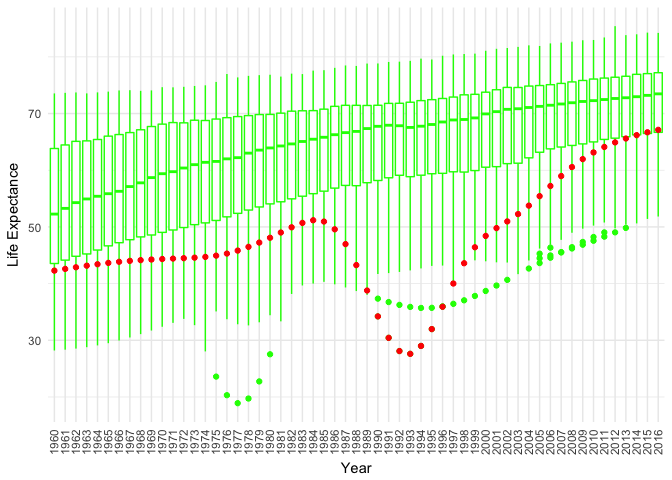

```r
WDIData %>% filter(`Indicator Code` == "SP.DYN.LE00.IN")  %>% .[,-c(2:4,62,63)] %>% gather(`Country Name`) %>% select(Year = `Country Name`, value) %>% filter(!is.na(value)) -> globalStat

WDIData %>% filter(`Country Name` == "Rwanda" & `Indicator Code` == "SP.DYN.LE00.IN") %>% .[,-c(2:4,62,63)] %>% gather(`Country Name`) %>% select(Year = `Country Name`, value) -> rwandaStat

ggplot() + geom_boxplot(data = globalStat, aes(Year, value), color = "green") + geom_point(data = rwandaStat, aes(Year, value), color = "red") + theme_minimal() + theme(axis.text.x=element_text(angle=90,hjust=1,vjust=0.5), legend.position="bottom") + ylab("Life Expectance")
```

۳. نمودار امید به زندگی و هزینه های بهداشتی را رسم کنید. چه نتیجه ایی می گیرید؟

```r
WDIData %>% filter(`Indicator Code` == "SP.DYN.LE00.IN") %>% rowwise() %>% mutate(Average = mean(c(`2000`,`2001`,`2002`,`2003`,`2004`,`2005`,`2006`,`2007`,`2008`,`2009`,`2010`,`2011`,`2012`,`2013`,`2014`,`2015`,`2016`,`2017`), na.rm = T)) %>% filter(!is.na(Average)) %>% select(Country = `Country Name`, AverageLifeExpectance = Average) -> lifeExpectance
WDIData %>% filter(`Indicator Code` == "SH.XPD.CHEX.GD.ZS") %>% rowwise() %>% mutate(Average = mean(c(`2000`,`2001`,`2002`,`2003`,`2004`,`2005`,`2006`,`2007`,`2008`,`2009`,`2010`,`2011`,`2012`,`2013`,`2014`,`2015`,`2016`,`2017`), na.rm = T)) %>% filter(!is.na(Average)) %>% select(Country =`Country Name`, AverageHealthExpenditure = Average) -> healthExpenditure
mergedData = merge(lifeExpectance, healthExpenditure) %>% arrange(desc(AverageLifeExpectance))
highchart() %>% hc_add_series(mergedData, type = "line", hcaes(x = Country, y = AverageLifeExpectance), name = "Life Expectance") %>% hc_add_series(mergedData, type="line", hcaes(x = Country, y = AverageHealthExpenditure), name = "Health Expenditure")
```

[interactive chart not shown]

با مقایسه امید به زندگی و درصد بودجه اختصاص داده شده به بخش سلامت نتوانستیم به نتیجه خاصی برسیم. شاید انجام این بررسی با میزان بودجه اختصاص داده شده به بخش سلامت نتایج بهتری بدهد که شاخص مربوط به آن در شاخص ها موجود نبود.

۴. آیا قدرت خرید خانواده های ایرانی در ۵۰ سال اخیر افزایش یافته است؟ برای این کار از داده های اقتصادی خانوار استفاده کنید.

```r
WDIData %>% filter(`Indicator Code` == "NE.CON.PRVT.PP.KD" & `Country Name` == "Iran, Islamic Rep.") %>% gather() -> purchasePowerData
purchasePowerData$key = as.numeric(purchasePowerData$key)
purchasePowerData$value = as.numeric(purchasePowerData$value)
hchart(purchasePowerData[35:61,] %>% select(Year = key, PurchasePower = value), "line", hcaes(Year, PurchasePower)) %>% hc_add_theme(hc_theme_sandsignika())
```

[interactive chart not shown]

داده های ۵۰ سال اخیر برای این شاخص در ۵۰ سال اخیر موجود نبود اما داده های ۲۵ سال اخیر نشان دهنده این افزایش در قدرت خرید مردم هستند.

۵. رشد اقتصادی ایران را با کشورهای دیگر در طول ۲۰ سال گذشته بر حسب بیست شاخص های اقتصادی مهم مانند تولید ناخالص ملی، تورم و … ارزیابی کنید! (برای هر شاخص از تصویرسازی استفاده کنید.)

ابتدا شاخص های اقتصادی که در ایران از سال ۱۹۹۵ تا ۲۰۱۶ اندازه گیری شده اند را مشخص می کنیم تا از بین آن ها ۲۰ شاخص مهم را انتخاب کنیم.

```r
economicIndicators = WDISeries %>% filter(str_detect(Topic, "Economic") | str_detect(Topic, "Financial"))
fullDataEconomicIndicators = WDIData %>% filter(`Indicator Code` %in% economicIndicators$`Series Code` & `Country Name` == "Iran, Islamic Rep.") %>% .[,c(1,3,4,40:61)] %>% na.omit()
```

حال از میان شاخص های به دست آمده بیست شاخص را انتخاب می کنیم و به ادامه بررسی می پردازیم

```r
selectedEconomicIndicators <- c("Agriculture, value added (% of GDP)",
                                "Exports of goods and services (% of GDP)",
                                "GDP (current US$)",
                                "GDP growth (annual %)",
                                "GDP per capita (current US$)",
                                "GNI, Atlas method (current US$)",
                                "Grants, excluding technical cooperation (BoP, current US$)",
                                "Imports of goods and services (% of GDP)",
                                "Industry, value added (% of GDP)",
                                "Inflation, GDP deflator (annual %)",
                                "Inflation, consumer prices (annual %)",
                                "Net ODA received per capita (current US$)",
                                "Services, etc., value added (% of GDP)",
                                "Technical cooperation grants (BoP, current US$)",
                                "Gross capital formation (% of GDP)",
                                "Gross domestic income (constant LCU)",
                                "Gross domestic savings (current LCU)",
                                "Gross national expenditure (% of GDP)",
                                "Household final consumption expenditure (annual % growth)",
                                "Manufacturing, value added (% of GDP)"
                                )
# check wether selected appropriate indicators
selectedEconomicIndicators %in% fullDataEconomicIndicators$`Indicator Name`
```

```
##  [1] TRUE TRUE TRUE TRUE TRUE TRUE TRUE TRUE TRUE TRUE TRUE TRUE TRUE TRUE
## [15] TRUE TRUE TRUE TRUE TRUE TRUE
```

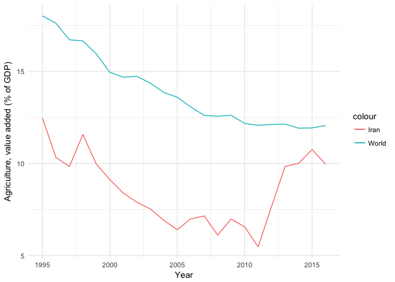

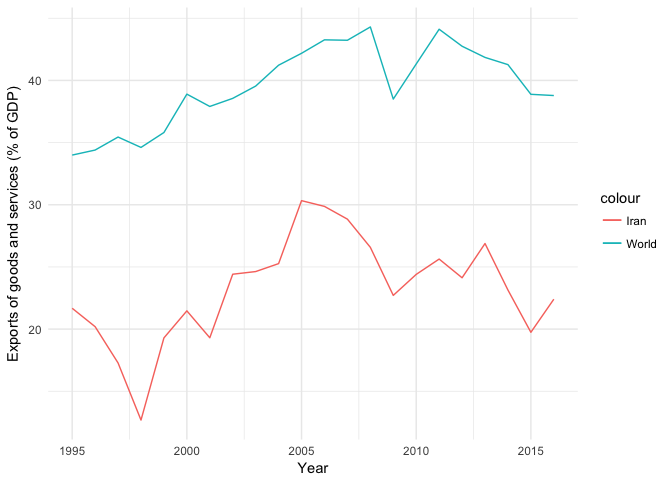

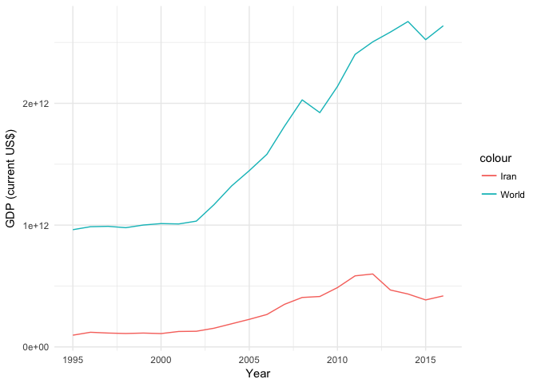

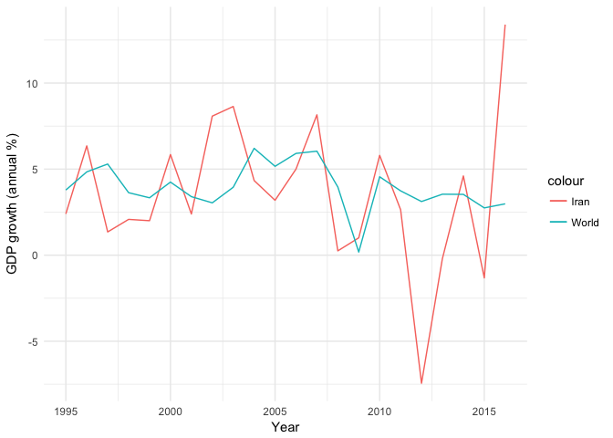

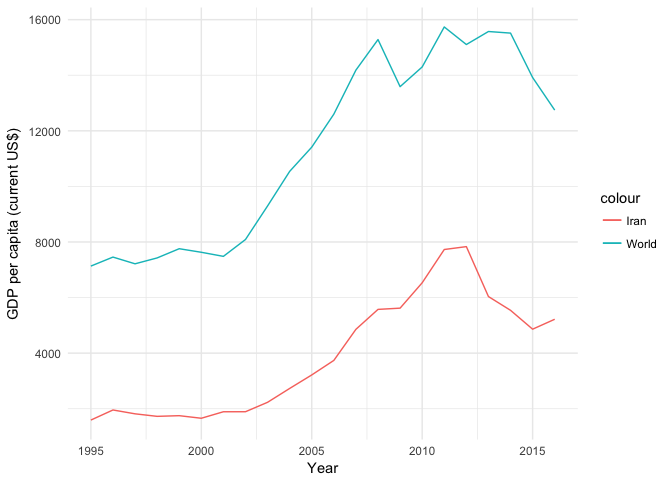

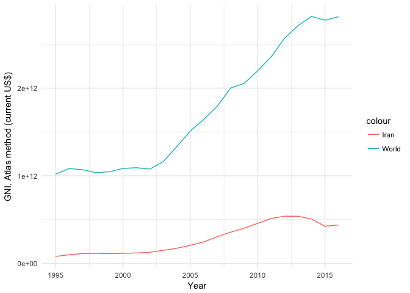

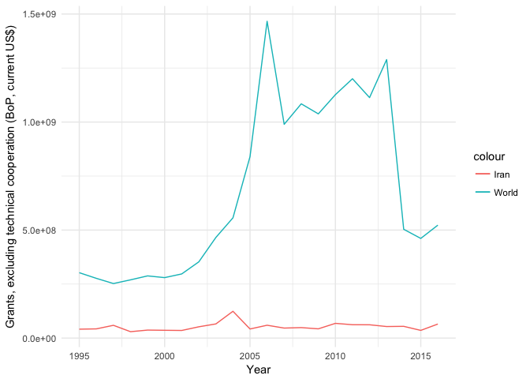

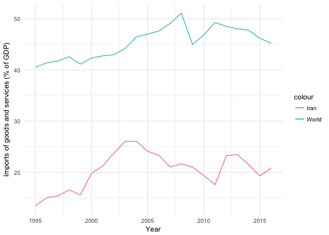

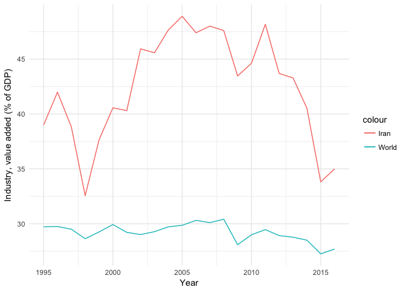

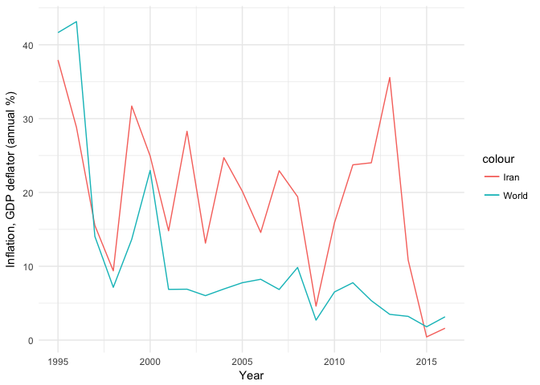

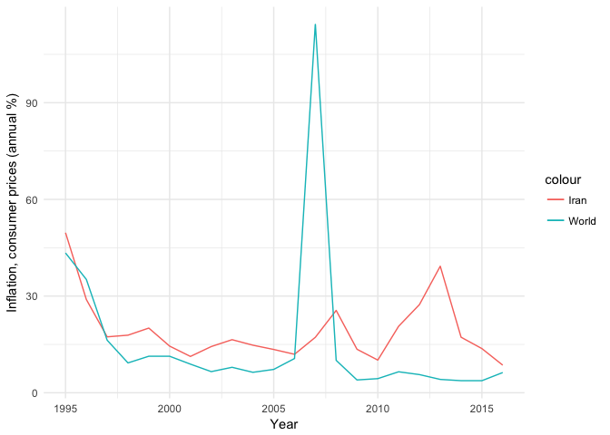

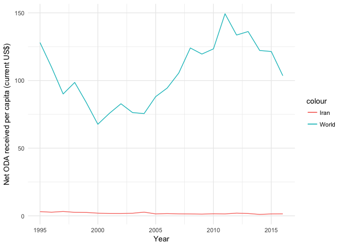

[8 more figures not shown]

```r
for(indicator in selectedEconomicIndicators){
  iran = fullDataEconomicIndicators %>% filter(`Indicator Name` == indicator) %>% .[,4:25] %>% gather()
  world = WDIData %>% filter(`Indicator Name` == indicator) %>% summarise(`1995` = mean(`1995`, na.rm = T), `1996` = mean(`1996`, na.rm = T), `1997` = mean(`1997`, na.rm = T), `1998` = mean(`1998`, na.rm = T), `1999` = mean(`1999`, na.rm = T), `2000` = mean(`2000`, na.rm = T), `2001` = mean(`2001`, na.rm = T), `2002` = mean(`2002`, na.rm = T), `2003` = mean(`2003`, na.rm = T), `2004` = mean(`2004`, na.rm = T),`2005` = mean(`2005`, na.rm = T) ,`2006` = mean(`2006`, na.rm = T), `2007` = mean(`2007`, na.rm = T), `2008` = mean(`2008`, na.rm = T), `2009` = mean(`2009`, na.rm = T), `2010` = mean(`2010`, na.rm = T), `2011` = mean(`2011`, na.rm = T), `2012` = mean(`2012`, na.rm = T), `2013` = mean(`2013`, na.rm = T), `2014` = mean(`2014`, na.rm = T), `2015` = mean(`2015`, na.rm = T), `2016` = mean(`2016`, na.rm = T)) %>% gather()
  iran$key = as.integer(iran$key)
  world$key = as.integer(world$key)
  print(ggplot() + geom_line(data = iran, aes(key, value, color = "Iran")) + geom_line(data = world, aes(key, value, color = "World")) + xlab("Year") + ylab(indicator) + theme_minimal())
}
```

۶. در قسمت قبل با استفاده از روش خوشه بندی k-means داده ها را به سه دسته تقسیم کنید. ایران در کدام دسته می گنجد؟ (پیش از خوشه بندی طبیعتا داده را باید پاکسازی و استاندارد سازی نمایید.)

در مقادیر اندازه گیری شده برای کشورها دسته های تجمعی ای وجود دارد که مشخص کننده مقدار شاخص ها در مناطق است. با کمک مقایسه کردن مقادیر برای مناطق ایران را با این مناطق مقایسه می کنیم تا تشخیص دهیم در کدام دسته قرار می گیرد.

```r
clustering.matrix = matrix(ncol = 20, nrow = 48)
rownames(clustering.matrix) = c(unique(WDIData$`Country Name`)[1:47], "Iran")
colnames(clustering.matrix) = selectedEconomicIndicators
i = 1
for(indicator in selectedEconomicIndicators){
  iran = mean((fullDataEconomicIndicators %>% filter(`Indicator Name` == indicator) %>% .[,4:25] %>% gather())$value)
  WDIData %>% filter(`Indicator Name` == indicator) %>% rowwise() %>% mutate(Average = mean(c(`1995`, `1996`,`1997` ,`1998`, `1999`, `2000`,`2001`,`2002`,`2003`,`2004`,`2005`,`2006`,`2007`,`2008`,`2009`,`2010`,`2011`,`2012`,`2013`,`2014`,`2015`,`2016`,`2017`), na.rm = T)) -> average
  clustering.matrix[,i] = c(average$Average[1:47], iran)
  i=i+1
}
#remove NA columns
clustering.matrix = clustering.matrix[, -c(7,14,16,17,18)]
clustering.matrix = na.omit(clustering.matrix)
cluster.frame = data.frame(Class = rownames(clustering.matrix), Cluster = kmeans(clustering.matrix, 3)$cluster)
cluster.frame %>% filter(Cluster == 3)
```

```
##                                                   Class Cluster
## 1                                            Arab World       3
## 2                                Caribbean small states       3
## 3                        Central Europe and the Baltics       3
## 4                            Early-demographic dividend       3
## 5           East Asia & Pacific (excluding high income)       3
## 6            East Asia & Pacific (IDA & IBRD countries)       3
## 7         Europe & Central Asia (excluding high income)       3
## 8          Europe & Central Asia (IDA & IBRD countries)       3
## 9                Heavily indebted poor countries (HIPC)       3
## 10                                            IDA blend       3
## 11                                             IDA only       3
## 12                                            IDA total       3
## 13                            Latin America & Caribbean       3
## 14    Latin America & Caribbean (excluding high income)       3
## 15 Latin America & the Caribbean (IDA & IBRD countries)       3
## 16         Least developed countries: UN classification       3
## 17                                           Low income       3
## 18                                  Lower middle income       3
## 19                           Middle East & North Africa       3
## 20   Middle East & North Africa (excluding high income)       3
## 21    Middle East & North Africa (IDA & IBRD countries)       3
## 22                             Pre-demographic dividend       3
## 23                                           South Asia       3
## 24                              South Asia (IDA & IBRD)       3
## 25                                   Sub-Saharan Africa       3
## 26           Sub-Saharan Africa (excluding high income)       3
## 27            Sub-Saharan Africa (IDA & IBRD countries)       3
## 28                                                 Iran       3
```

۷. به وسیله تحلیل مولفه اصلی بعد داده رو به دو کاهش دهید سپس خوشه های به دست آمده در قسمت قبل را بر روی آن نمایش دهید. آیا عملکرد روش خوشه بندی شما مطلوب بوده است؟

```r
economicIndicator.pca = prcomp(clustering.matrix)
pca.cluster.frame = data.frame(Class = rownames(clustering.matrix), PC1 = economicIndicator.pca$x[,1], PC2 = economicIndicator.pca$x[,2], Cluster = cluster.frame$Cluster)
hchart(pca.cluster.frame, type = "point", hcaes(PC1, PC2, color = Cluster, group = Class)) %>% hc_legend(enabled = F)
```

[interactive chart not shown]

به نظر می رسد خوشه بندی تا حد خوبی دقیق بوده است. بالا بردن تعداد گروه ها در k-means می توانست گروه های دقیق تری بدهد ولی در حال حاضر داده ها تقریبا به سه دسته اعضای پیمان های خاص، اروپا و آمریکای شمالی، کشورهای در حال توسعه شامل آسیا، خاورمیانه و آمریکای جنوبی تقسیم شده اند.

۸. با استفاده از داده روشی برای پیش بینی رشد اقتصادی ایران در سال آینده ارائه دهید.

از یک مدل خطی فیت شده بر اساس داده های سال های مختلف ایران استفاده می کنیم که بر اساس سال میزان رشد GDP را تعیین می کند و بر این اساس میزان رشد را برای سال 2019 حدس می زنیم.

```r
WDIData %>% filter(`Country Name` == "Iran, Islamic Rep." & `Indicator Name` == "GDP growth (annual %)") %>% .[,6:61] %>% gather() %>% select(Year = key, GDPGrowth = value) %>% mutate(Year = as.integer(Year)) %>% lm(formula = GDPGrowth ~ Year) -> GDPGrowth.lm
summary(GDPGrowth.lm)
```

```
##
## Call:
## lm(formula = GDPGrowth ~ Year, data = .)
##
## Residuals:
##      Min       1Q   Median       3Q      Max
## -26.9846  -2.5248   0.9781   4.6464  18.0324
##
## Coefficients:
##              Estimate Std. Error t value Pr(>|t|)
## (Intercept) 249.01319  135.58637   1.837   0.0718 .
## Year         -0.12304    0.06818  -1.805   0.0767 .
## ---
## Signif. codes:  0 '***' 0.001 '**' 0.01 '*' 0.05 '.' 0.1 ' ' 1
##
## Residual standard error: 8.247 on 54 degrees of freedom
## Multiple R-squared:  0.05688,    Adjusted R-squared:  0.03941
## F-statistic: 3.257 on 1 and 54 DF,  p-value: 0.07671
```

```r
predict(GDPGrowth.lm, data.frame(Year = c(2019)))
```

```
##         1
## 0.5861801
```

مدل خوبی از داده های موجود به دست نیامد ولی با این حال این مدل میزان پیشرفت شاخص تولید ناخالص ملی یعنی GND را برابر حدود ۰.۶ درصد برای سال آینده پیش بینی کرده است.

۹. سوالهای ۵ تا ۷ را ابتدا برای ۲۰ شاخص سلامت سپس بر حسب ۲۰ شاخص آموزشی تکرار کنید.

شاخص های سلامت و آموزش که داده های کافی برای آن ها موجود است:

```r
healthIndicators = WDISeries %>% filter(str_detect(Topic, "Health"))
fullDataHealthIndicators = WDIData %>% filter(`Indicator Code` %in% healthIndicators$`Series Code` & `Country Name` == "Iran, Islamic Rep.") %>% .[,c(1,3,4,40:61)] %>% na.omit()

educationIndicators = WDISeries %>% filter(str_detect(Topic, "Education"))
fullDataEducationIndicators = WDIData %>% filter(`Indicator Code` %in% educationIndicators$`Series Code` & `Country Name` == "Iran, Islamic Rep.") %>% .[,c(1,3,4,40:61)] %>% na.omit()
```

حال از میان این شاخص ها چند شاخص را انتخاب می کنیم و بررسی ها را بر روی آن ها انجام می دهیم. از آن جایی که در میان شاخص های آموزش تنها ۵ شاخص دارای اطلاعات مورد نیاز هستند مجبوریم تعداد را به ۵ شاخص کاهش دهیم.

```r
selectedHealthIndicators <- c(
    "Age dependency ratio (% of working-age population)",
    "Birth rate, crude (per 1,000 people)",
    "Death rate, crude (per 1,000 people)",
    "Fertility rate, total (births per woman)",
    "Life expectancy at birth, female (years)",
    "Life expectancy at birth, male (years)",
    "Life expectancy at birth, total (years)",
    "Mortality rate, infant (per 1,000 live births)",
    "Mortality rate, neonatal (per 1,000 live births)",
    "Mortality rate, under-5 (per 1,000 live births)",
    "Population ages 0-14 (% of total)",
    "Population ages 15-64 (% of total)",
    "Population ages 65 and above (% of total)",
    "Population growth (annual %)",
    "Population, female (% of total)",
    "Population, male (% of total)",
    "Population, total",
    "Prevalence of HIV, female (% ages 15-24)",
    "Prevalence of HIV, male (% ages 15-24)",
    "Prevalence of HIV, total (% of population ages 15-49)"
)
selectedEducationIndicators = fullDataEducationIndicators$`Indicator Name`
# check wether selected appropriate indicators
selectedHealthIndicators %in% fullDataHealthIndicators$`Indicator Name`
```

```
##  [1] TRUE TRUE TRUE TRUE TRUE TRUE TRUE TRUE TRUE TRUE TRUE TRUE TRUE TRUE
## [15] TRUE TRUE TRUE TRUE TRUE TRUE
```

نمودارهای مربوط به شاخص های بخش سلامت:

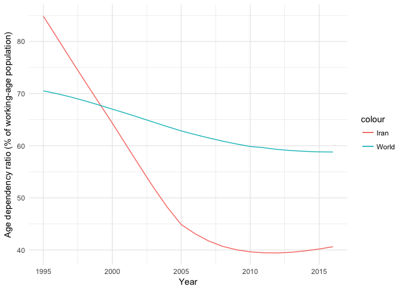

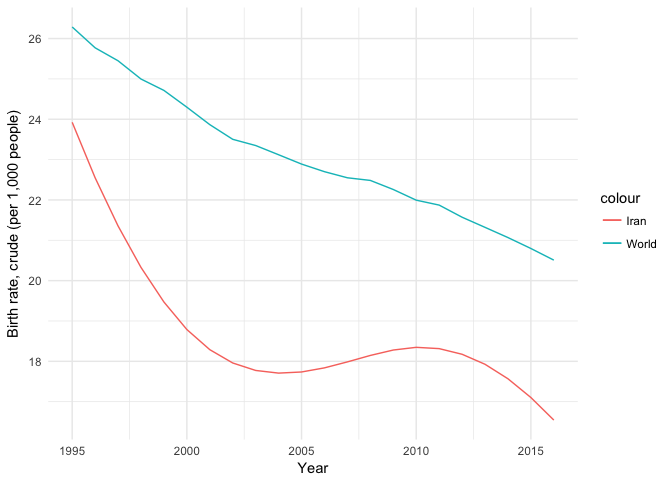

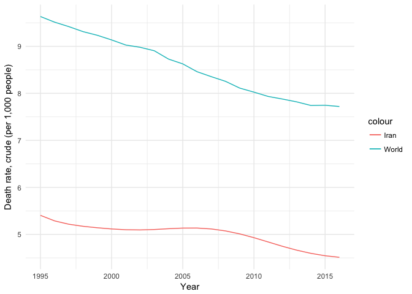

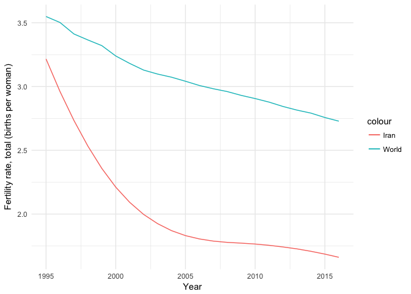

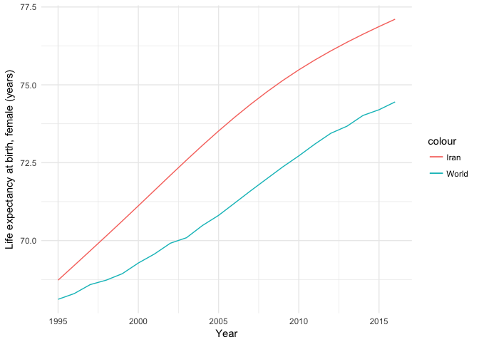

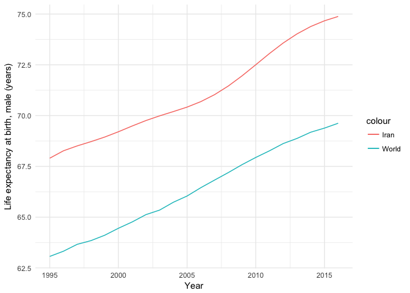

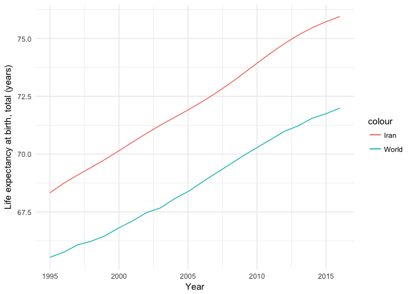

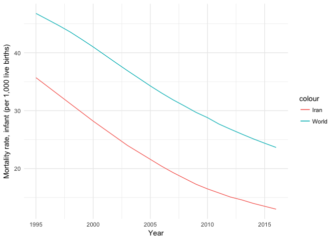

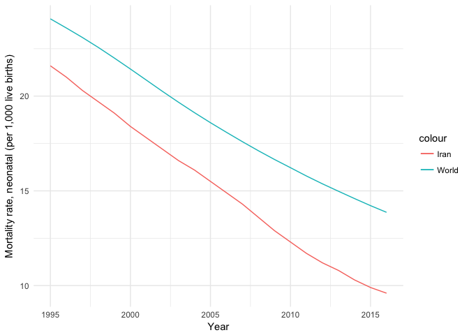

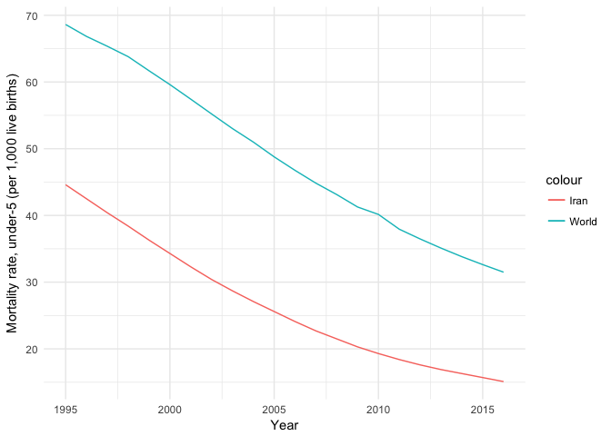

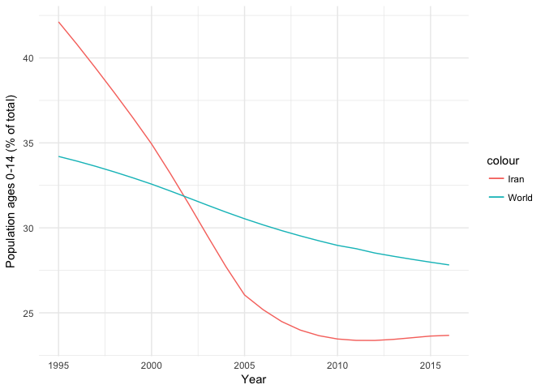

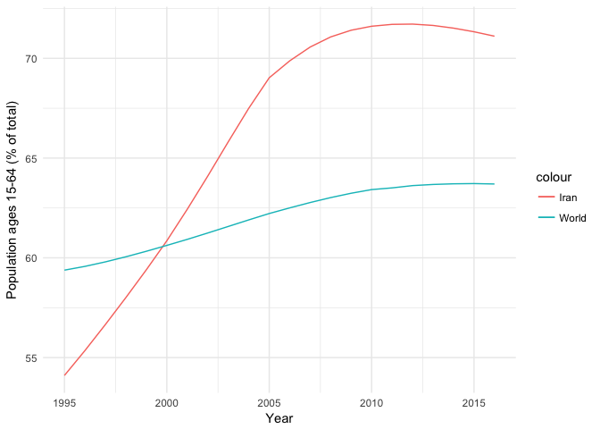

[8 more figures not shown]

```r
for(indicator in selectedHealthIndicators){
  iran = fullDataHealthIndicators %>% filter(`Indicator Name` == indicator) %>% .[,4:25] %>% gather()
  world = WDIData %>% filter(`Indicator Name` == indicator) %>% summarise(`1995` = mean(`1995`, na.rm = T), `1996` = mean(`1996`, na.rm = T), `1997` = mean(`1997`, na.rm = T), `1998` = mean(`1998`, na.rm = T), `1999` = mean(`1999`, na.rm = T), `2000` = mean(`2000`, na.rm = T), `2001` = mean(`2001`, na.rm = T), `2002` = mean(`2002`, na.rm = T), `2003` = mean(`2003`, na.rm = T), `2004` = mean(`2004`, na.rm = T),`2005` = mean(`2005`, na.rm = T) ,`2006` = mean(`2006`, na.rm = T), `2007` = mean(`2007`, na.rm = T), `2008` = mean(`2008`, na.rm = T), `2009` = mean(`2009`, na.rm = T), `2010` = mean(`2010`, na.rm = T), `2011` = mean(`2011`, na.rm = T), `2012` = mean(`2012`, na.rm = T), `2013` = mean(`2013`, na.rm = T), `2014` = mean(`2014`, na.rm = T), `2015` = mean(`2015`, na.rm = T), `2016` = mean(`2016`, na.rm = T)) %>% gather()
  iran$key = as.integer(iran$key)
  world$key = as.integer(world$key)
  print(ggplot() + geom_line(data = iran, aes(key, value, color = "Iran")) + geom_line(data = world, aes(key, value, color = "World")) + xlab("Year") + ylab(indicator) + theme_minimal())
}
```

نمودارهای مربوط به شاخص های بخش آموزش:

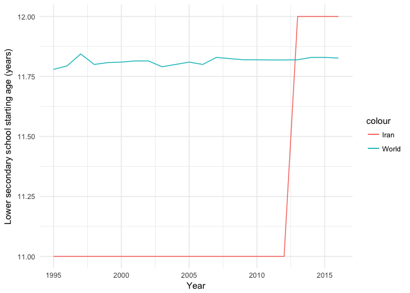

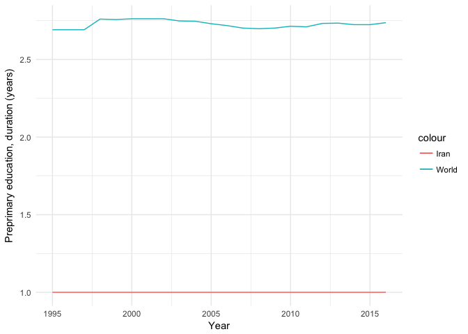

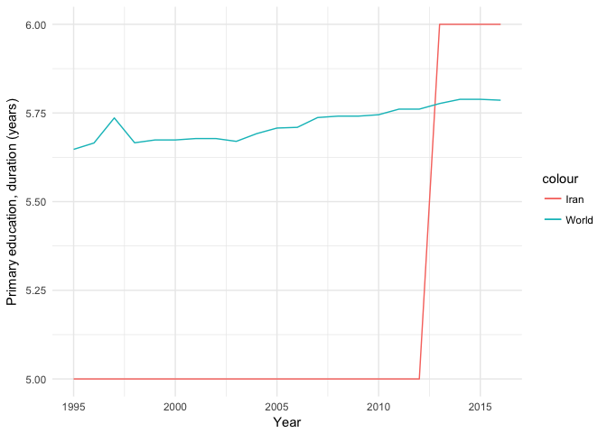

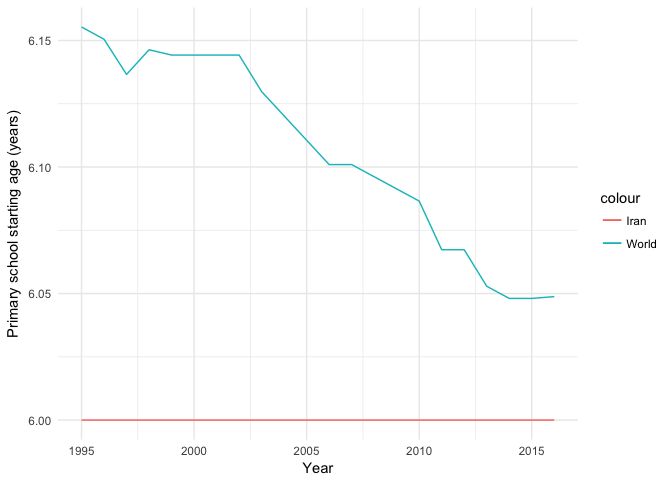

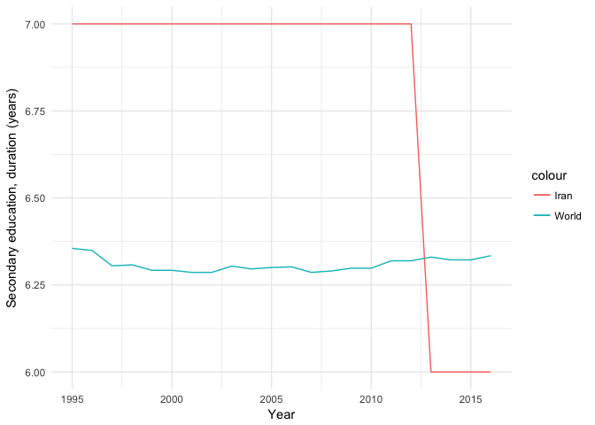

```r
for(indicator in selectedEducationIndicators){
  iran = fullDataEducationIndicators %>% filter(`Indicator Name` == indicator) %>% .[,4:25] %>% gather()
  world = WDIData %>% filter(`Indicator Name` == indicator) %>% summarise(`1995` = mean(`1995`, na.rm = T), `1996` = mean(`1996`, na.rm = T), `1997` = mean(`1997`, na.rm = T), `1998` = mean(`1998`, na.rm = T), `1999` = mean(`1999`, na.rm = T), `2000` = mean(`2000`, na.rm = T), `2001` = mean(`2001`, na.rm = T), `2002` = mean(`2002`, na.rm = T), `2003` = mean(`2003`, na.rm = T), `2004` = mean(`2004`, na.rm = T),`2005` = mean(`2005`, na.rm = T) ,`2006` = mean(`2006`, na.rm = T), `2007` = mean(`2007`, na.rm = T), `2008` = mean(`2008`, na.rm = T), `2009` = mean(`2009`, na.rm = T), `2010` = mean(`2010`, na.rm = T), `2011` = mean(`2011`, na.rm = T), `2012` = mean(`2012`, na.rm = T), `2013` = mean(`2013`, na.rm = T), `2014` = mean(`2014`, na.rm = T), `2015` = mean(`2015`, na.rm = T), `2016` = mean(`2016`, na.rm = T)) %>% gather()
  iran$key = as.integer(iran$key)
  world$key = as.integer(world$key)
  print(ggplot() + geom_line(data = iran, aes(key, value, color = "Iran")) + geom_line(data = world, aes(key, value, color = "World")) + xlab("Year") + ylab(indicator) + theme_minimal())
}
```

حال کلاسترینگ به سه دسته را با توجه به داده های مربوط به بخش سلامت انجام می دهیم و نتیجه را بر روی نمودار PC1 و PC2 نمایش می دهیم.

```r
clustering.matrix = matrix(ncol = 20, nrow = 48)
rownames(clustering.matrix) = c(unique(WDIData$`Country Name`)[1:47], "Iran")
colnames(clustering.matrix) = selectedHealthIndicators
i = 1
for(indicator in selectedHealthIndicators){
  iran = mean((fullDataHealthIndicators %>% filter(`Indicator Name` == indicator) %>% .[,4:25] %>% gather())$value)
  WDIData %>% filter(`Indicator Name` == indicator) %>% rowwise() %>% mutate(Average = mean(c(`1995`, `1996`,`1997` ,`1998`, `1999`, `2000`,`2001`,`2002`,`2003`,`2004`,`2005`,`2006`,`2007`,`2008`,`2009`,`2010`,`2011`,`2012`,`2013`,`2014`,`2015`,`2016`,`2017`), na.rm = T)) -> average
  clustering.matrix[,i] = c(average$Average[1:47], iran)
  i=i+1
}
#remove NA columns
clustering.matrix = clustering.matrix[, -c(18,19,20)]
clustering.matrix = na.omit(clustering.matrix)
cluster.frame = data.frame(Class = rownames(clustering.matrix), Cluster = kmeans(clustering.matrix, 3)$cluster)
#pca
healthIndicator.pca = prcomp(clustering.matrix)
pca.cluster.frame = data.frame(Class = rownames(clustering.matrix), PC1 = healthIndicator.pca$x[,1], PC2 = healthIndicator.pca$x[,2], Cluster = cluster.frame$Cluster)
hchart(pca.cluster.frame, type = "point", hcaes(PC1, PC2, color = Cluster, group = Class)) %>% hc_legend(enabled = F)
```

[interactive chart not shown]

این باز نتیجه کلاسترینگ بسیار جالب است و نشان دهنده این است که ایران در شاخص های سلامتی هم گروه کشورهای اروپایی و آمریکای شمالی قرار داد.  
حال این مراحل را برای شاخص های آموزش انجام می دهیم و نتیجه را بررسی می کنیم.

```r
clustering.matrix = matrix(ncol = 5, nrow = 48)
rownames(clustering.matrix) = c(unique(WDIData$`Country Name`)[1:47], "Iran")
colnames(clustering.matrix) = selectedEducationIndicators
i = 1
for(indicator in selectedEducationIndicators){
  iran = mean((fullDataEducationIndicators %>% filter(`Indicator Name` == indicator) %>% .[,4:25] %>% gather())$value)
  WDIData %>% filter(`Indicator Name` == indicator) %>% rowwise() %>% mutate(Average = mean(c(`1995`, `1996`,`1997` ,`1998`, `1999`, `2000`,`2001`,`2002`,`2003`,`2004`,`2005`,`2006`,`2007`,`2008`,`2009`,`2010`,`2011`,`2012`,`2013`,`2014`,`2015`,`2016`,`2017`), na.rm = T)) -> average
  clustering.matrix[,i] = c(average$Average[1:47], iran)
  i=i+1
}
#remove NA columns
clustering.matrix = clustering.matrix[, -c(1,4)]
clustering.matrix = na.omit(clustering.matrix)
cluster.frame = data.frame(Class = rownames(clustering.matrix), Cluster = kmeans(clustering.matrix, 3)$cluster)
#pca
educationIndicator.pca = prcomp(clustering.matrix)
pca.cluster.frame = data.frame(Class = rownames(clustering.matrix), PC1 = educationIndicator.pca$x[,1], PC2 = educationIndicator.pca$x[,2], Cluster = cluster.frame$Cluster)
hchart(pca.cluster.frame, type = "point", hcaes(PC1, PC2, color = Cluster, group = Class)) %>% hc_legend(enabled = F)
```

[interactive chart not shown]

در شاخص های آموزشی نیز ایران در گروه کشورهای عربی و خاورمیانه قرار گرفته که به دلیل کم بودن شاخص های مورد بررسی می تواند نتیجه نادقیقی باشد.

۱۰. کشورهای دنیا را بر حسب ۶۰ شاخص اقتصادی، سلامت و آموزش با روش سلسله مراتبی خوشه بندی کرده و دندروگرام آن را رسم نمایید. اگر داده ها بر سه دسته تقسیم شوند ایران در کدام دسته می گنجد؟

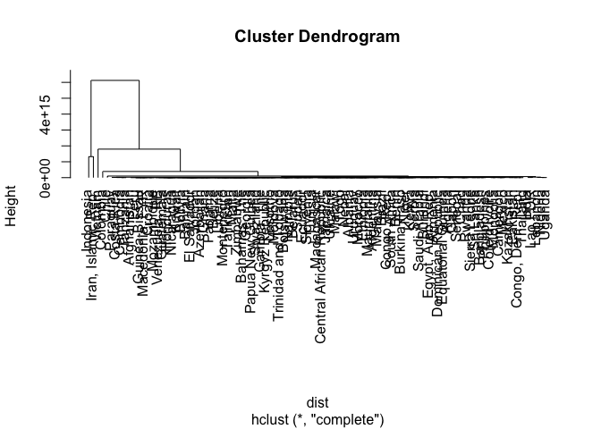

```r
clustering.matrix = matrix(ncol = 45, nrow = 264-47)
rownames(clustering.matrix) = c(unique(WDIData$`Country Name`)[48:264])
colnames(clustering.matrix) = c(selectedEconomicIndicators, selectedHealthIndicators, selectedEducationIndicators)
i = 1
for(indicator in selectedEconomicIndicators){
  WDIData %>% filter(`Indicator Name` == indicator) %>% rowwise() %>% mutate(Average = mean(c(`1995`, `1996`,`1997` ,`1998`, `1999`, `2000`,`2001`,`2002`,`2003`,`2004`,`2005`,`2006`,`2007`,`2008`,`2009`,`2010`,`2011`,`2012`,`2013`,`2014`,`2015`,`2016`,`2017`), na.rm = T)) -> average
  clustering.matrix[,i] = c(average$Average[48:264])
  i=i+1
}
for(indicator in selectedHealthIndicators){
  WDIData %>% filter(`Indicator Name` == indicator) %>% rowwise() %>% mutate(Average = mean(c(`1995`, `1996`,`1997` ,`1998`, `1999`, `2000`,`2001`,`2002`,`2003`,`2004`,`2005`,`2006`,`2007`,`2008`,`2009`,`2010`,`2011`,`2012`,`2013`,`2014`,`2015`,`2016`,`2017`), na.rm = T)) -> average
  clustering.matrix[,i] = c(average$Average[48:264])
  i=i+1
}
for(indicator in selectedEducationIndicators){
  WDIData %>% filter(`Indicator Name` == indicator) %>% rowwise() %>% mutate(Average = mean(c(`1995`, `1996`,`1997` ,`1998`, `1999`, `2000`,`2001`,`2002`,`2003`,`2004`,`2005`,`2006`,`2007`,`2008`,`2009`,`2010`,`2011`,`2012`,`2013`,`2014`,`2015`,`2016`,`2017`), na.rm = T)) -> average
  clustering.matrix[,i] = c(average$Average[48:264])
  i=i+1
}
clustering.matrix = na.omit(clustering.matrix)
dist = stats::dist(data.frame(clustering.matrix),method = "euclidean")
clus = hclust(dist,method = "complete")
plot(clus, hang = -1)
```

با توجه به دندوگرام به دست آمده، به نظر می رسد ایران در کلاستری جدا از بسیاری کشورهای دیگر قرار گرفته است که علت آن نامعلوم است.

```r
hcut= cutree(clus,k=3)
hcut[hcut==2]
```

```
##          Indonesia Iran, Islamic Rep.
##                  2                  2
```

در این دسته بندی ایران در گروهی در کنار اندونزی قرار گرفته است.

۱۱. سه یافته جالب از داده ها استخراج کنید.

بررسی تفاوت امید به زندگی در خانوم ها و آقایان و یافتن کشورهای مناسب تر برای آقایان و خانم ها بر این اساس بررسی ای کاملا جنسیتی و در نوع خود جالب است!

```r
WDIData %>% filter(`Indicator Code` == "SP.DYN.LE00.FE.IN")  %>% .[,-c(2:4,62,63)] %>% gather(`Country Name`) %>% select(Year = `Country Name`, value) %>% filter(!is.na(value)) %>% group_by(Year) %>% summarise(AverageLifeExpectance = mean(value)) -> femaleLife

WDIData %>% filter(`Indicator Code` == "SP.DYN.LE00.MA.IN")  %>% .[,-c(2:4,62,63)] %>% gather(`Country Name`) %>% select(Year = `Country Name`, value) %>% filter(!is.na(value)) %>% group_by(Year) %>% summarise(AverageLifeExpectance = mean(value)) -> maleLife

highchart() %>% hc_add_series(data = femaleLife, type = "line", hcaes(x = as.numeric(Year), y = AverageLifeExpectance), name = "Female") %>% hc_add_series(data = maleLife, type = "line", hcaes(x = as.numeric(Year), y = AverageLifeExpectance), name = "Male")
```

[interactive chart not shown]

به نظر می رسد همواره در طول تاریخ امید به زندگی خانم ها ۲ تا ۵ سال بیشتر از آقایان بوده است!

```r
countries = unique(WDIData$`Country Name`)[-(1:47)]
WDIData %>% filter(`Indicator Code` == "SP.DYN.LE00.FE.IN" & `Country Name` %in% countries)  %>% .[,-c(2:4,62,63)] %>% gather(`Country Name`) %>% select(Year = `Country Name`, value) -> femaleLifeCountryBased
femaleLifeCountryBased$Country = rep(countries, length(unique(femaleLifeCountryBased$Year)))
femaleLifeCountryBased = femaleLifeCountryBased %>% group_by(Country) %>% summarise(AverageLifeExpectance = mean(value, na.rm = T)) %>% filter(!is.na(AverageLifeExpectance)) %>% select(Country, AverageFemaleLifeExpectance = AverageLifeExpectance)

WDIData %>% filter(`Indicator Code` == "SP.DYN.LE00.MA.IN" & `Country Name` %in% countries)  %>% .[,-c(2:4,62,63)] %>% gather(`Country Name`) %>% select(Year = `Country Name`, value) -> maleLifeCountryBased
maleLifeCountryBased$Country = rep(countries, length(unique(maleLifeCountryBased$Year)))
maleLifeCountryBased = maleLifeCountryBased %>% group_by(Country) %>% summarise(AverageLifeExpectance = mean(value, na.rm = T)) %>% filter(!is.na(AverageLifeExpectance)) %>% select(Country, AverageMaleLifeExpectance = AverageLifeExpectance)

merge(femaleLifeCountryBased, maleLifeCountryBased) %>% mutate(Diff = AverageFemaleLifeExpectance - AverageMaleLifeExpectance) %>% arrange(desc(Diff)) -> sexedLifeExpectance

hchart(sexedLifeExpectance, "line", hcaes(Country, Diff), name = "Life Expectance Difference") %>% hc_add_theme(hc_theme_smpl())
```

[interactive chart not shown]

نمودار بالا نشان می دهد در هیچ کشوری امید به زندگی برای آقایان بیشتر از خانم ها نیست که جای تاسف دارد! با توجه به نتایج به دست آمده زنان کشورهای روسیه، قزاقستان، جمهوری لتونی و استونی چیزی حدود بیش از ۱۰ سال بیشتر از مردان این کشورها زندگی می کنند و در مقابل مردان کشورهای مالدیو، هند، بوتان و بنگلادش از بیشترین شانس برای زندگی پا به پای زنان این کشورها دارند!

```r
sexedLifeExpectance %>% arrange(desc(AverageMaleLifeExpectance)) %>% head(5)
```

```
##          Country AverageFemaleLifeExpectance AverageMaleLifeExpectance
## 1     San Marino                    86.80000                  84.10000
## 2 Cayman Islands                    84.70000                  79.80000
## 3  Liechtenstein                    83.02609                  77.60870
## 4  Faroe Islands                    81.37576                  75.66061
## 5        Iceland                    80.33596                  75.47070
##       Diff
## 1 2.700000
## 2 4.900000
## 3 5.417391
## 4 5.715152
## 5 4.865263
```

```r
sexedLifeExpectance %>% arrange(desc(AverageFemaleLifeExpectance)) %>% head(5)
```

```
##          Country AverageFemaleLifeExpectance AverageMaleLifeExpectance
## 1     San Marino                    86.80000                  84.10000
## 2 Cayman Islands                    84.70000                  79.80000
## 3  Liechtenstein                    83.02609                  77.60870
## 4  Faroe Islands                    81.37576                  75.66061
## 5        Bermuda                    81.20048                  74.86457
##       Diff
## 1 2.700000
## 2 4.900000
## 3 5.417391
## 4 5.715152
## 5 6.335905
```